# Twitter Sentiment Analysis

Group 10

16 September 2017

### 1.Introduction

We focused on fetching the tweets with `#ThursdayThoughts` from twitter and analyse the sentiments.

Following are the necesssary libraries that are needed.

```r
if (Sys.getenv("JAVA_HOME")!="") Sys.setenv(JAVA_HOME="")
require(twitteR)
require(tm)
require(stringr)
require(qdap)
require(ggplot2)
require(wordcloud)
require(topicmodels)
require(tidytext)
require(dplyr)
```

### 2.Data Fetching

- Define your twitter authentication details (this part of code is hidden)
- Establish a connect with twitter developer API by passing the authentication details to `setup_twitter_oauth` function.
- Pull recent 2,500 tweets containing the hash tag **#ThursdayThoughts**.
- Store the tweets in a dataframe and convert it to corpus.

```r
setup_twitter_oauth(consumerkey,consumersecret,accesstoken,accesssecret)
ThursdayThoughts= searchTwitter(searchString ='#ThursdayThoughts',
                                n=2500 , lang = 'en')
TT_dataframe = twListToDF(ThursdayThoughts)
TT_dataframe$created <- as.Date(TT_dataframe$created,format = "%d-%m-%Y %H:%M")

Tweets = as.character(TT_dataframe$text)
Tweets_Corpus = Corpus(VectorSource(Tweets))
```

### 3.Data Cleaning

- The corpus is subjected to cleaning by removing the `usernames` that are followed by **@**,
- `URLs` are removed.
- `Pure Numbers` i.e like 54 but not iphone8 (aplha-numeric), are removed.
- `Puctuations & whitespaces` are removed.
- Entire text is converted into `lower case`.
- `Abbrevations` are replaced.
- All the words are subjected to `stemming`.
- `Stopwords` are removed.

```r
removeUsernameInRT <- function(x) str_replace_all(x,"(?<=@)[^\\s:]+",'')
Tweets_Corpus = tm_map(Tweets_Corpus, content_transformer(removeUsernameInRT))

removeURL <- function(x) gsub("http[^[:space:]]*", "", x)
Tweets_Corpus = tm_map(Tweets_Corpus, content_transformer(removeURL))

removeCompleteNumbers <- function(x) str_replace_all(x,'(?<=[:blank:])[0-9]+(?=[:blank:])', '')
Tweets_Corpus = tm_map(Tweets_Corpus, content_transformer(removeCompleteNumbers))

Tweets_Corpus = tm_map(Tweets_Corpus,removePunctuation)
removeSingle <- function(x) gsub(" . ", " ", x)
Tweets_Corpus = tm_map(Tweets_Corpus, content_transformer(removeSingle))
Tweets_Corpus = tm_map(Tweets_Corpus,stripWhitespace)
Tweets_Corpus = tm_map(Tweets_Corpus,content_transformer(tolower))
Tweets_Corpus = tm_map(Tweets_Corpus, content_transformer(replace_abbreviation))

Tweets_Corpus_Filtered = Tweets_Corpus
Tweets_Corpus<-tm_map(Tweets_Corpus, stemDocument,language = 'english')
stemCompletionuserDefined <- function(x,dictionary) {
  x = unlist(strsplit(as.character(x)," "))
  x = x[x !=""]
  x = stemCompletion(x, dictionary = dictionary)
  x = paste(x, sep="", collapse=" ")
  PlainTextDocument(stripWhitespace(x))
}
Tweets_Corpus = lapply(Tweets_Corpus, stemCompletionuserDefined, dictionary=Tweets_Corpus_Filtered)
temp = character()
for(i in 1: nrow(TT_dataframe)){
  temp[i] = Tweets_Corpus[[i]]$content
}
temp_df = data.frame(text = temp, stringsAsFactors = F)
Tweets_Corpus = Corpus(VectorSource(temp_df$text))
Tweets_Corpus = tm_map(Tweets_Corpus,
                       removeWords,c(stopwords('en'),'rt','thursdaythoughts','thursdaythought'))
```

### 4.Word Frequency Analysis

- Convert the corpus into `TermDocumentMatrix`.
- Calculate the frequency count of each word and create a dataframe of words & their frequencies.

```r
Tweets_Corpus_TDM = TermDocumentMatrix(Tweets_Corpus)
Tweets_Corpus_TDM_M = as.matrix(Tweets_Corpus_TDM)
termFrequency = rowSums(Tweets_Corpus_TDM_M)
termFrequency = sort(termFrequency,decreasing =T)
```

Following is the chart displaying the most used 25 words and their frequencies.

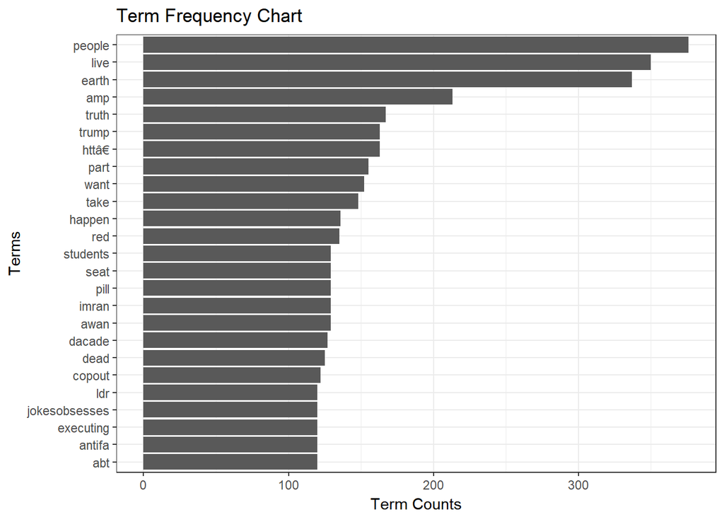

```r
frequency_df <- data.frame(term = names(termFrequency), freq= termFrequency)
ggplot(frequency_df[1:25,], aes(reorder(term, freq),freq)) +
  theme_bw() +
  geom_bar(stat = "identity") +
  coord_flip() +
  labs(list(title="Term Frequency Chart", x="Terms", y="Term Counts"))
```

Following the sample spare matrix representing the words live & people present in the frst 50 tweets

```r
index <- which(dimnames(Tweets_Corpus_TDM)$Terms %in% c("live", "people"))
as.matrix(Tweets_Corpus_TDM[index,1:50])
```

```
##         Docs
## Terms    1 2 3 4 5 6 7 8 9 10 11 12 13 14 15 16 17 18 19 20 21 22 23 24 25
##   live   0 0 0 0 0 0 0 0 0  0  0  0  0  0  0  0  0  0  0  0  0  0  0  1  0
##   people 0 0 0 0 0 0 0 0 0  0  0  0  0  0  0  0  0  0  0  0  0  0  0  1  0
##         Docs
## Terms    26 27 28 29 30 31 32 33 34 35 36 37 38 39 40 41 42 43 44 45 46 47
##   live    0  0  0  0  0  0  1  0  0  0  0  0  0  0  0  0  0  0  0  0  0  0
##   people  0  0  0  0  0  0  1  0  0  0  0  0  0  0  0  0  0  0  0  0  0  0
##         Docs
## Terms    48 49 50
##   live    0  0  0
##   people  0  0  0
```

Following is the word cloud consisting the most frequently used words

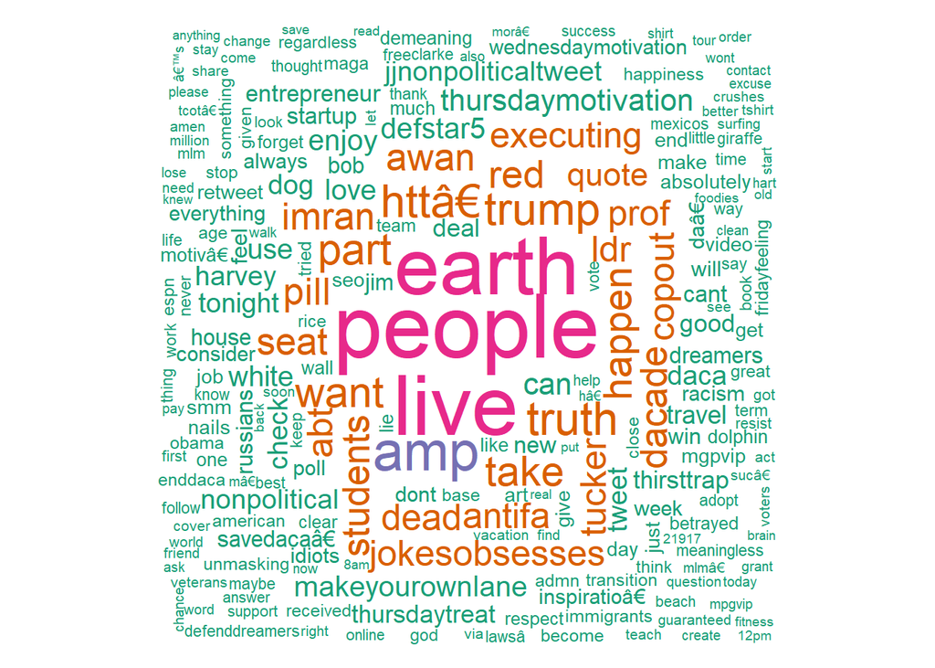

```r
pal<- brewer.pal(4, "Dark2")
wordcloud(words = names(termFrequency),
          freq = termFrequency,
          min.freq = 2,
          random.order = F,
          colors = pal,
          max.words = 250)
```

### 5.Topic Modeling

Here we found top 5 discussed topics and their words

```r
Tweets_Corpus_DTM <- as.DocumentTermMatrix(Tweets_Corpus_TDM)
rowTotals <- apply(Tweets_Corpus_DTM , 1, sum)
NullDocs <- Tweets_Corpus_DTM[rowTotals==0, ]
Tweets_Corpus_DTM   <- Tweets_Corpus_DTM[rowTotals> 0, ]
if (length(NullDocs$dimnames$Docs) > 0) {
  TT_dataframe <- TT_dataframe[-as.numeric(NullDocs$dimnames$Docs),]
}
lda <- LDA(Tweets_Corpus_DTM, k = 5)
term <- terms(lda, 5)
term
```

```
##      Topic 1  Topic 2              Topic 3               Topic 4
## [1,] "people" "thursdaymotivation" "enjoy"               "want"
## [2,] "live"   "love"               "dog"                 "take"
## [3,] "earth"  "check"              "tonight"             "truth"
## [4,] "part"   "dacade"             "harvey"              "happen"
## [5,] "amp"    "thirsttrap"         "jjnonpoliticaltweet" "red"
##      Topic 5
## [1,] "quote"
## [2,] "defstar5"
## [3,] "makeyourownlane"
## [4,] "entrepreneur"
## [5,] "startup"
```

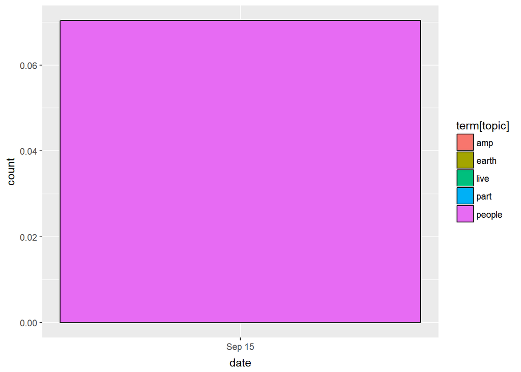

```r
topics<- topics(lda)
topics_df<- data.frame(date=(TT_dataframe$created), topic = topics)
qplot(date, ..count.., data=topics_df,
      geom ="density",
       fill= term[topic],position="stack")
```

### 6.Sentiment Analysis

Here we tried to find the positive and negative sentiment words and various emotional sentiment words * Took the common words from `bing` lexicon to get the +ve or -ve sentiment details for each word. * Applied `afinn` lexicon on to the above result to get the sentiment scores for each word.

```r
colnames(frequency_df) = c('word','freq')
sentiment_df = frequency_df %>%
  inner_join(get_sentiments('bing'), by='word')
sentiment_df = sentiment_df %>%
  inner_join(get_sentiments('afinn'),by='word')
```

Following is the graph showing the top used words and their +/- Sentiment

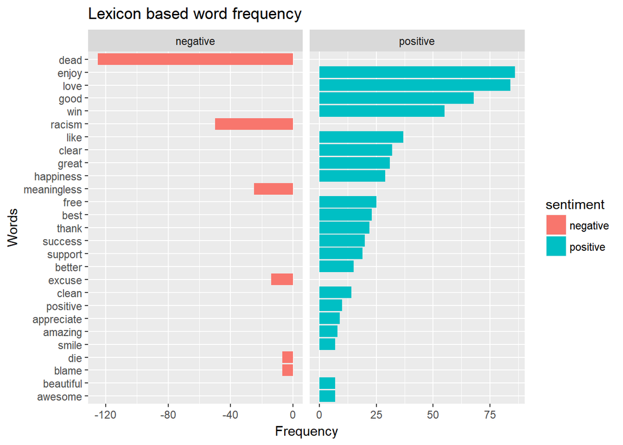

```r
sentiment_df %>%
  top_n(25,freq) %>%
  mutate(x1 = reorder(word,freq),
         y1 = ifelse(sentiment=='positive',freq,-freq)) %>%
  ggplot(aes(x=x1, y= y1, fill = sentiment)) +
  geom_col(stat='identity') +
  coord_flip()+
  facet_wrap(~sentiment, scales = "free_x")+
  ggtitle('Lexicon based word frequency')+
  xlab('Words')+ylab('Frequency')
```

Here we tried the same but with regards to various emotional sentiments

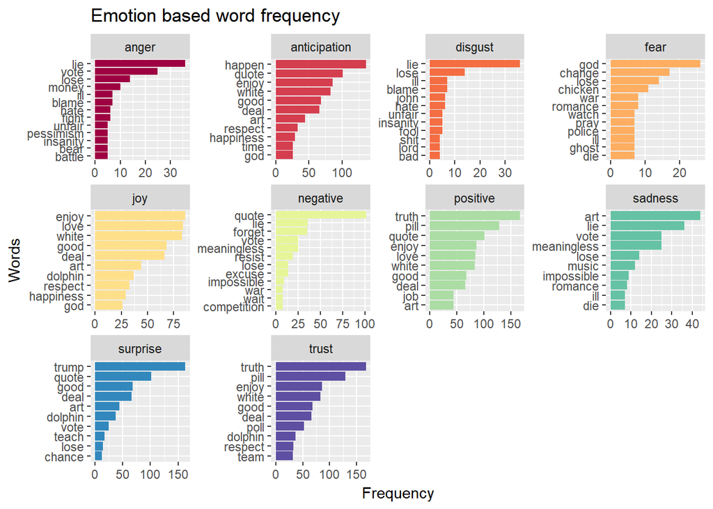

```r
Emotion_sentiment_df = frequency_df %>%
  inner_join(get_sentiments('nrc'), by='word')
Emotion_sentiment_df %>%
  group_by(sentiment) %>%
  top_n(10,freq) %>%
  ungroup() %>%
  mutate(word = reorder(word, freq)) %>%
  ggplot(aes(x = word, y = freq , fill  = sentiment)) +
  scale_fill_brewer(palette="Spectral")+
  geom_col(show.legend = FALSE) +
  facet_wrap(~ sentiment, scales = "free") +
  coord_flip()+
  ggtitle('Emotion based word frequency')+
  xlab('Words')+ylab('Frequency')
```